# Exercise list

1. Build and fit model with the same data used on `04`. Use it with MobileNetV2 architecture feature extraction (`mobilenet_v2_100_224/feature_vector`) from TensorFlow Hub. How does it compare to the 2 other models done before?
2. Name 3 different image classification models on TensorFlow Hub that we haven't used.
3. Build a model to classify images of two different things you've taken photos of.
   - Use any feature extraction model to your liking.
   - Aim to have at least 10 images of each class
4. What is the current best performing model on ImageNet? (Check `sotabench.com`)

Set up timestamp to keep note of when this notebook was last run

```python
# add timestamp
import datetime
print(f'This notebook was last run at: {datetime.datetime.now()}')
```

```
This notebook was last run at: 2025-09-02 18:48:40.878530
```

### Creating data loaders

Use `ImageDataGenerator` and `flow_from_directory` methods to load in images.

```python
# setup data inputs
import tensorflow as tf
from tensorflow.keras.preprocessing.image import ImageDataGenerator

IMAGE_SHAPE = (224,224)
BATCH_SIZE = 32

train_dir = '10_food_classes_10_percent/train/'
test_dir = '10_food_classes_10_percent/test'

datagen = ImageDataGenerator(1./255)

print('Training images:')
train_10_percent_data=datagen.flow_from_directory(train_dir,
                                                  target_size=IMAGE_SHAPE,
                                                  batch_size=BATCH_SIZE,
                                                  class_mode='categorical')

print('Testing images:')
test_10_percent_data=datagen.flow_from_directory(test_dir,
                                                 target_size=IMAGE_SHAPE,
                                                 batch_size=BATCH_SIZE,
                                                 class_mode='categorical')
```

```
Training images:
Found 750 images belonging to 10 classes.
Testing images:
Found 2500 images belonging to 10 classes.
```

### Setup callbacks

We want to setup tensorboard callbacks to keep track of model progression, by creating logs for every epoch of training.

This will be setup as a function, as it will be applied to multiple models.

```python
# setup tensorboard callback
def create_tensorboard_callback(dir_name, experiment_name):
    log_dir = dir_name + '/' + experiment_name + '/' + datetime.datetime.now().strftime('%Y%m%d-%H%M%S')
    tensorboard_callback = tf.keras.callbacks.TensorBoard(
        log_dir=log_dir)

    print(f'Saving TensorBoard log files in:{log_dir}')
    return tensorboard_callback
```

### What model to choose?

As stated at the top of the notebook for the exercise, we will use `MobileNetV2` architecture.

We will pull in the url associated to the model.

```python
!pip install kagglehub
```

[output not shown]

```python
# add url to variable
mobilenet_url = "https://tfhub.dev/google/imagenet/mobilenet_v2_100_224/feature_vector/5"
```

Now let's create the model as a function, so it can be applied to other models if needed

```python
import tensorflow_hub as hub
import tensorflow.keras as keras

def create_model(model_url, num_classes=10):
    # download pretrained model and have it as a keras layer
    feature_extractor_layer = hub.KerasLayer(model_url,
                                             trainable=False, # freeze underlying layers
                                             name='feature_extraction_layer',
                                             input_shape=IMAGE_SHAPE+(3,)) # defining image shape size, 3 is the colour channels

    model = tf.keras.Sequential([
        tf.keras.layers.Lambda(lambda x: feature_extractor_layer(x)), # using 'feature_extractor_layer' as base/main layer
        tf.keras.layers.Dense(num_classes, activation='softmax', name='output_layer') # custom output layer with our specified number of classes
    ])

    return model
```

As the function is created, let's use the architecture on the model function, using:

categorical crossentropy > loss function

adam > optimizer

accuracy > metric

```python
# create model
mobilenet_model = create_model(mobilenet_url, num_classes=train_10_percent_data.num_classes)

# compile
mobilenet_model.compile(loss='categorical_crossentropy',
                        optimizer=tf.keras.optimizers.Adam(),
                        metrics=['Accuracy'])
```

It's time to fit the model and create our callback with `create_tensorboard_callback`

```python
# fit the model
mobilenet_history = mobilenet_model.fit(train_10_percent_data,
                                        epochs=5,
                                        steps_per_epoch=len(train_10_percent_data),
                                        validation_data=test_10_percent_data,
                                        validation_steps=len(test_10_percent_data),
                                        callbacks=[create_tensorboard_callback(dir_name='tensorflow_hub',
                                                                              experiment_name='mobilenetv2')])
```

```
Saving TensorBoard log files in:tensorflow_hub/mobilenetv2/20250906-230718
24/24 ━━━━━━━━━━━━━━━━━━━━ 47s 2s/step - Accuracy: 0.1200 - loss: 2.4355 - val_Accuracy: 0.1596 - val_loss: 2.2904
24/24 ━━━━━━━━━━━━━━━━━━━━ 22s 948ms/step - Accuracy: 0.2280 - loss: 2.1233 - val_Accuracy: 0.1972 - val_loss: 2.2022
24/24 ━━━━━━━━━━━━━━━━━━━━ 22s 939ms/step - Accuracy: 0.2827 - loss: 2.0083 - val_Accuracy: 0.2500 - val_loss: 2.0832
24/24 ━━━━━━━━━━━━━━━━━━━━ 23s 984ms/step - Accuracy: 0.3440 - loss: 1.8681 - val_Accuracy: 0.2776 - val_loss: 2.0294
24/24 ━━━━━━━━━━━━━━━━━━━━ 22s 964ms/step - Accuracy: 0.3933 - loss: 1.7812 - val_Accuracy: 0.2836 - val_loss: 2.0280
```

Let's plot out the training logs. The scores above however don't really instill much confidence in accuracy.

```python
# this can be turned into a helper.py script - aka a code that serves a function/utility for the main project, that you would call back upon
import matplotlib.pyplot as plt

# plot the validation and training data separately
def plot_loss_curves(history):
    '''
    returns separate loss curves for training and validation metrics
    '''
    loss = history.history['loss']
    val_loss = history.history['val_loss']

    accuracy = history.history['Accuracy']
    val_accuracy = history.history['val_Accuracy']

    epochs = range(len(history.history['loss']))

    # plot loss
    plt.plot(epochs,loss,label='training_loss')
    plt.plot(epochs,val_loss,label='val_loss')
    plt.title('Loss')
    plt.xlabel('Epochs')
    plt.legend()

    # plot accuracy
    plt.figure()
    plt.plot(epochs,accuracy,label='training_accuracy')
    plt.plot(epochs,val_accuracy,label='val_accuracy')
    plt.title('Accuracy')
    plt.xlabel('Epochs')
    plt.legend()
```

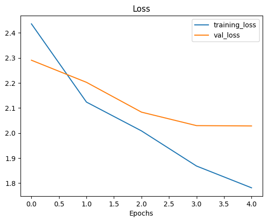

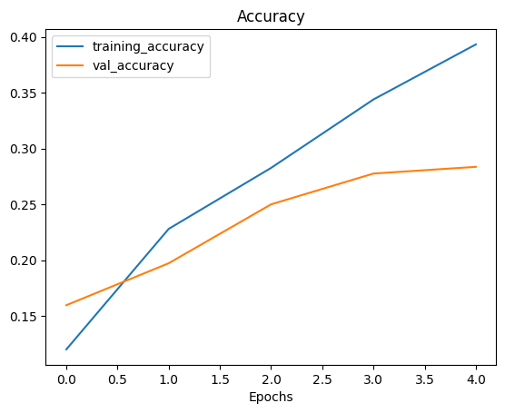

```python
plot_loss_curves(mobilenet_history)
```

`MobilenetV2` can be visually seen as not being as quick of a learner, compared to `resnet50V2`, and `efficientnetB0` from the other workbook. However based on its trajectory, we can tell that it will further improve on it's prediction. Though it is most likely redundant, as the other 2 models produce quicker results, with much better accuracy.

```python
mobilenet_model.summary()
```

```
Model: "sequential_1"
```

```
┏━━━━━━━━━━━━━━━━━━━━━━━━━━━━━━━━━┳━━━━━━━━━━━━━━━━━━━━━━━━┳━━━━━━━━━━━━━━━┓
┃ Layer (type)                    ┃ Output Shape           ┃       Param # ┃
┡━━━━━━━━━━━━━━━━━━━━━━━━━━━━━━━━━╇━━━━━━━━━━━━━━━━━━━━━━━━╇━━━━━━━━━━━━━━━┩
│ lambda_1 (Lambda)               │ (None, 1280)           │             0 │
├─────────────────────────────────┼────────────────────────┼───────────────┤
│ output_layer (Dense)            │ (None, 10)             │        12,810 │
└─────────────────────────────────┴────────────────────────┴───────────────┘
```

```
 Total params: 38,432 (150.13 KB)
```

```
 Trainable params: 12,810 (50.04 KB)
```

```
 Non-trainable params: 0 (0.00 B)
```

```
 Optimizer params: 25,622 (100.09 KB)
```

## Name 3 different image classification models on Kaggle that we haven't used

1. Inception
2. Nasnet
3. MobileViT

## What is the best performing model on `ImageNet`

Probably AlexNet

## Getting at least 10 images of 2 separate things, and another 10 for its test set to train on

Let's start by checking the files in my personally generated `rat and dog` dataset.

```python
# checking number images in the dataset directory
import os

# walk through directory, and list number of files
for dirpath, dirnames, filenames in os.walk('rat_and_dog'):
    print(f'There are {len(dirnames)} directories and {len(filenames)} images in "{dirpath}"')
```

```
There are 2 directories and 0 images in "rat_and_dog"
There are 2 directories and 0 images in "rat_and_dog\test"
There are 0 directories and 5 images in "rat_and_dog\test\dog"
There are 0 directories and 5 images in "rat_and_dog\test\rat"
There are 2 directories and 0 images in "rat_and_dog\train"
There are 0 directories and 10 images in "rat_and_dog\train\rat"
There are 0 directories and 10 images in "rat_and_dog\train\dog"
```

Create data loaders with `ImageDataGenerator` class along with `flow_from_directory` to load our images.

```python
# setup our data loader
import tensorflow as tf
from tensorflow.keras.preprocessing.image import ImageDataGenerator

IMAGE_SHAPE=(224,224)
# no batch_size, as our dataset is too small to render it useful

train_dir='rat_and_dog/train'
test_dir='rat_and_dog/test'

datagen=ImageDataGenerator(rescale=1/255.)

print('Training Images:')
train_rat_dog=datagen.flow_from_directory(train_dir,
                                          target_size=IMAGE_SHAPE,
                                          class_mode='categorical')

test_rat_dog=datagen.flow_from_directory(test_dir,
                                         target_size=IMAGE_SHAPE,
                                         class_mode='categorical')
```

```
Training Images:
Found 20 images belonging to 2 classes.
Found 10 images belonging to 2 classes.
```

We've already created the functions related to the model training. So I will utilize them, rather than recreating them.

```python
# create model with previous functions
rat_dog_mobilenet = create_model(mobilenet_url, num_classes=train_rat_dog.num_classes)

# compile model
rat_dog_mobilenet.compile(loss='categorical_crossentropy',
                          optimizer=tf.keras.optimizers.Adam(),
                          metrics=['Accuracy'])
```

Time to fit the model. Instead of 5 epochs, let's try 100 due to size of dataset

```python
# fit the model
rat_dog_history = rat_dog_mobilenet.fit(train_rat_dog,
                                        epochs=100,
                                        steps_per_epoch=len(train_rat_dog),
                                        validation_data=test_rat_dog,
                                        validation_steps=len(test_rat_dog),
                                        callbacks=[create_tensorboard_callback(dir_name='tensorflow_hub',
                                                                               experiment_name='mobilenetv2')])
```

```
Saving TensorBoard log files in:tensorflow_hub/mobilenetv2/20250912-215449
```

```
1/1 ━━━━━━━━━━━━━━━━━━━━ 6s 6s/step - Accuracy: 0.5000 - loss: 1.0511 - val_Accuracy: 0.3000 - val_loss: 1.0625
1/1 ━━━━━━━━━━━━━━━━━━━━ 1s 994ms/step - Accuracy: 0.7000 - loss: 0.6895 - val_Accuracy: 0.5000 - val_loss: 0.8135
1/1 ━━━━━━━━━━━━━━━━━━━━ 1s 1s/step - Accuracy: 0.8500 - loss: 0.4639 - val_Accuracy: 0.6000 - val_loss: 0.6315
1/1 ━━━━━━━━━━━━━━━━━━━━ 1s 1s/step - Accuracy: 1.0000 - loss: 0.3263 - val_Accuracy: 0.7000 - val_loss: 0.4893
1/1 ━━━━━━━━━━━━━━━━━━━━ 1s 1s/step - Accuracy: 1.0000 - loss: 0.2327 - val_Accuracy: 0.8000 - val_loss: 0.3711
1/1 ━━━━━━━━━━━━━━━━━━━━ 1s 1s/step - Accuracy: 1.0000 - loss: 0.1638 - val_Accuracy: 0.9000 - val_loss: 0.2732
1/1 ━━━━━━━━━━━━━━━━━━━━ 1s 1s/step - Accuracy: 1.0000 - loss: 0.1130 - val_Accuracy: 1.0000 - val_loss: 0.1966
1/1 ━━━━━━━━━━━━━━━━━━━━ 1s 1s/step - Accuracy: 1.0000 - loss: 0.0773 - val_Accuracy: 1.0000 - val_loss: 0.1406
1/1 ━━━━━━━━━━━━━━━━━━━━ 1s 1s/step - Accuracy: 1.0000 - loss: 0.0533 - val_Accuracy: 1.0000 - val_loss: 0.1015
1/1 ━━━━━━━━━━━━━━━━━━━━ 1s 998ms/step - Accuracy: 1.0000 - loss: 0.0374 - val_Accuracy: 1.0000 - val_loss: 0.0750
1/1 ━━━━━━━━━━━━━━━━━━━━ 1s 974ms/step - Accuracy: 1.0000 - loss: 0.0270 - val_Accuracy: 1.0000 - val_loss: 0.0571
1/1 ━━━━━━━━━━━━━━━━━━━━ 1s 1s/step - Accuracy: 1.0000 - loss: 0.0201 - val_Accuracy: 1.0000 - val_loss: 0.0449
1/1 ━━━━━━━━━━━━━━━━━━━━ 1s 1s/step - Accuracy: 1.0000 - loss: 0.0155 - val_Accuracy: 1.0000 - val_loss: 0.0364
1/1 ━━━━━━━━━━━━━━━━━━━━ 1s 1s/step - Accuracy: 1.0000 - loss: 0.0122 - val_Accuracy: 1.0000 - val_loss: 0.0303
1/1 ━━━━━━━━━━━━━━━━━━━━ 1s 1s/step - Accuracy: 1.0000 - loss: 0.0099 - val_Accuracy: 1.0000 - val_loss: 0.0259
1/1 ━━━━━━━━━━━━━━━━━━━━ 1s 1s/step - Accuracy: 1.0000 - loss: 0.0082 - val_Accuracy: 1.0000 - val_loss: 0.0225
1/1 ━━━━━━━━━━━━━━━━━━━━ 1s 1s/step - Accuracy: 1.0000 - loss: 0.0070 - val_Accuracy: 1.0000 - val_loss: 0.0200
1/1 ━━━━━━━━━━━━━━━━━━━━ 1s 1s/step - Accuracy: 1.0000 - loss: 0.0060 - val_Accuracy: 1.0000 - val_loss: 0.0180
1/1 ━━━━━━━━━━━━━━━━━━━━ 1s 962ms/step - Accuracy: 1.0000 - loss: 0.0052 - val_Accuracy: 1.0000 - val_loss: 0.0163
1/1 ━━━━━━━━━━━━━━━━━━━━ 1s 988ms/step - Accuracy: 1.0000 - loss: 0.0046 - val_Accuracy: 1.0000 - val_loss: 0.0150
1/1 ━━━━━━━━━━━━━━━━━━━━ 1s 965ms/step - Accuracy: 1.0000 - loss: 0.0041 - val_Accuracy: 1.0000 - val_loss: 0.0139
1/1 ━━━━━━━━━━━━━━━━━━━━ 1s 989ms/step - Accuracy: 1.0000 - loss: 0.0037 - val_Accuracy: 1.0000 - val_loss: 0.0130
1/1 ━━━━━━━━━━━━━━━━━━━━ 1s 986ms/step - Accuracy: 1.0000 - loss: 0.0034 - val_Accuracy: 1.0000 - val_loss: 0.0122
1/1 ━━━━━━━━━━━━━━━━━━━━ 1s 993ms/step - Accuracy: 1.0000 - loss: 0.0031 - val_Accuracy: 1.0000 - val_loss: 0.0115
1/1 ━━━━━━━━━━━━━━━━━━━━ 1s 1s/step - Accuracy: 1.0000 - loss: 0.0029 - val_Accuracy: 1.0000 - val_loss: 0.0109
1/1 ━━━━━━━━━━━━━━━━━━━━ 1s 1s/step - Accuracy: 1.0000 - loss: 0.0027 - val_Accuracy: 1.0000 - val_loss: 0.0103
1/1 ━━━━━━━━━━━━━━━━━━━━ 1s 966ms/step - Accuracy: 1.0000 - loss: 0.0025 - val_Accuracy: 1.0000 - val_loss: 0.0099
1/1 ━━━━━━━━━━━━━━━━━━━━ 1s 973ms/step - Accuracy: 1.0000 - loss: 0.0023 - val_Accuracy: 1.0000 - val_loss: 0.0095
1/1 ━━━━━━━━━━━━━━━━━━━━ 1s 970ms/step - Accuracy: 1.0000 - loss: 0.0022 - val_Accuracy: 1.0000 - val_loss: 0.0091
1/1 ━━━━━━━━━━━━━━━━━━━━ 1s 967ms/step - Accuracy: 1.0000 - loss: 0.0021 - val_Accuracy: 1.0000 - val_loss: 0.0088
1/1 ━━━━━━━━━━━━━━━━━━━━ 1s 974ms/step - Accuracy: 1.0000 - loss: 0.0020 - val_Accuracy: 1.0000 - val_loss: 0.0085
1/1 ━━━━━━━━━━━━━━━━━━━━ 1s 1s/step - Accuracy: 1.0000 - loss: 0.0019 - val_Accuracy: 1.0000 - val_loss: 0.0082
1/1 ━━━━━━━━━━━━━━━━━━━━ 1s 1s/step - Accuracy: 1.0000 - loss: 0.0018 - val_Accuracy: 1.0000 - val_loss: 0.0079
1/1 ━━━━━━━━━━━━━━━━━━━━ 1s 1s/step - Accuracy: 1.0000 - loss: 0.0017 - val_Accuracy: 1.0000 - val_loss: 0.0077
1/1 ━━━━━━━━━━━━━━━━━━━━ 1s 1s/step - Accuracy: 1.0000 - loss: 0.0017 - val_Accuracy: 1.0000 - val_loss: 0.0075
1/1 ━━━━━━━━━━━━━━━━━━━━ 1s 1s/step - Accuracy: 1.0000 - loss: 0.0016 - val_Accuracy: 1.0000 - val_loss: 0.0073
1/1 ━━━━━━━━━━━━━━━━━━━━ 1s 1s/step - Accuracy: 1.0000 - loss: 0.0015 - val_Accuracy: 1.0000 - val_loss: 0.0071
1/1 ━━━━━━━━━━━━━━━━━━━━ 1s 1s/step - Accuracy: 1.0000 - loss: 0.0015 - val_Accuracy: 1.0000 - val_loss: 0.0070
1/1 ━━━━━━━━━━━━━━━━━━━━ 1s 1s/step - Accuracy: 1.0000 - loss: 0.0014 - val_Accuracy: 1.0000 - val_loss: 0.0068
1/1 ━━━━━━━━━━━━━━━━━━━━ 1s 1s/step - Accuracy: 1.0000 - loss: 0.0014 - val_Accuracy: 1.0000 - val_loss: 0.0067
```

[output cut: 45 more lines]

```
1/1 ━━━━━━━━━━━━━━━━━━━━ 1s 1s/step - Accuracy: 1.0000 - loss: 8.2761e-04 - val_Accuracy: 1.0000 - val_loss: 0.0043
1/1 ━━━━━━━━━━━━━━━━━━━━ 1s 1s/step - Accuracy: 1.0000 - loss: 8.2296e-04 - val_Accuracy: 1.0000 - val_loss: 0.0042
1/1 ━━━━━━━━━━━━━━━━━━━━ 1s 1s/step - Accuracy: 1.0000 - loss: 8.1842e-04 - val_Accuracy: 1.0000 - val_loss: 0.0042
1/1 ━━━━━━━━━━━━━━━━━━━━ 1s 1s/step - Accuracy: 1.0000 - loss: 8.1394e-04 - val_Accuracy: 1.0000 - val_loss: 0.0042
1/1 ━━━━━━━━━━━━━━━━━━━━ 1s 1s/step - Accuracy: 1.0000 - loss: 8.0952e-04 - val_Accuracy: 1.0000 - val_loss: 0.0042
1/1 ━━━━━━━━━━━━━━━━━━━━ 1s 1s/step - Accuracy: 1.0000 - loss: 8.0517e-04 - val_Accuracy: 1.0000 - val_loss: 0.0042
1/1 ━━━━━━━━━━━━━━━━━━━━ 1s 1s/step - Accuracy: 1.0000 - loss: 8.0090e-04 - val_Accuracy: 1.0000 - val_loss: 0.0041
1/1 ━━━━━━━━━━━━━━━━━━━━ 1s 1000ms/step - Accuracy: 1.0000 - loss: 7.9667e-04 - val_Accuracy: 1.0000 - val_loss: 0.0041
1/1 ━━━━━━━━━━━━━━━━━━━━ 1s 1s/step - Accuracy: 1.0000 - loss: 7.9251e-04 - val_Accuracy: 1.0000 - val_loss: 0.0041
1/1 ━━━━━━━━━━━━━━━━━━━━ 1s 1s/step - Accuracy: 1.0000 - loss: 7.8838e-04 - val_Accuracy: 1.0000 - val_loss: 0.0041
1/1 ━━━━━━━━━━━━━━━━━━━━ 1s 1s/step - Accuracy: 1.0000 - loss: 7.8432e-04 - val_Accuracy: 1.0000 - val_loss: 0.0041
1/1 ━━━━━━━━━━━━━━━━━━━━ 1s 1s/step - Accuracy: 1.0000 - loss: 7.8032e-04 - val_Accuracy: 1.0000 - val_loss: 0.0040
1/1 ━━━━━━━━━━━━━━━━━━━━ 1s 1s/step - Accuracy: 1.0000 - loss: 7.7637e-04 - val_Accuracy: 1.0000 - val_loss: 0.0040
1/1 ━━━━━━━━━━━━━━━━━━━━ 1s 1s/step - Accuracy: 1.0000 - loss: 7.7244e-04 - val_Accuracy: 1.0000 - val_loss: 0.0040
1/1 ━━━━━━━━━━━━━━━━━━━━ 1s 999ms/step - Accuracy: 1.0000 - loss: 7.6858e-04 - val_Accuracy: 1.0000 - val_loss: 0.0040
```

Now let's pull out the graph function and see accuracy and loss

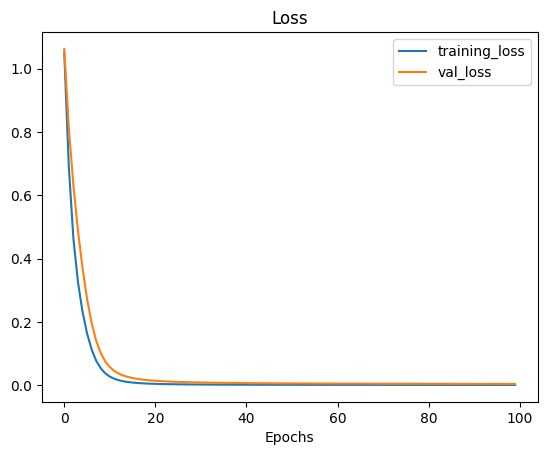

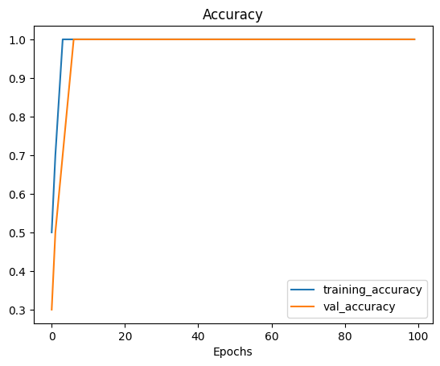

```python
plot_loss_curves(rat_dog_history)
```

Amazing model results! After about 5 to 6 epochs, the model is able to 100% predict which class the image is. However, it's confidence level was not very high. Which is indicated by the loss curve, where the model had probability values to be substantial enough on the latter/wrong category. It took about 20 epochs for the model to almost certainly predict the category with extreme confidence.